# Estimación Bayesiana Multinivel con brms

No Pooling, Partial Pooling y Full Pooling — GDP per Cápita Mundial

Hector Najera

2026-05-14

```r
library(brms)
library(cmdstanr)
library(tidyverse)
library(patchwork)
library(bayesplot)
library(tidybayes)
library(ggrepel)

# Usar CmdStanR como backend
options(brms.backend = "cmdstanr")
set_cmdstan_path()  # usa la instalacion detectada automaticamente
theme_set(theme_minimal(base_size = 13))
```

# 1. Datos Simulados

Simulamos un panel de 120 países en 6 regiones. Algunos países tienen muchos años de datos (*datos ricos*) y otros muy pocos (*datos escasos*). El objetivo es modelar cómo el **gasto público** (% del PIB) se relaciona con el **PIB per cápita** (log).

```r
set.seed(2024)

regiones <- c("América Latina", "Europa Occidental", "Asia Oriental",
              "África Subsahariana", "Medio Oriente", "Asia Central")

# Parámetros regionales "verdaderos"
region_intercepts <- c(8.5, 10.2, 9.8, 7.4, 9.1, 8.0)
region_slopes     <- c(0.08, 0.04, 0.06, 0.12, 0.07, 0.09)

paises_por_region <- c(25, 20, 22, 28, 15, 10)

datos_panel <- map2_dfr(
  seq_along(regiones), regiones,
  function(r_idx, r_nombre) {
    n_paises <- paises_por_region[r_idx]

    # Efectos aleatorios por país (alrededor del promedio regional)
    alpha_j <- rnorm(n_paises, region_intercepts[r_idx], 0.5)
    beta_j  <- rnorm(n_paises, region_slopes[r_idx],     0.02)

    map_dfr(seq_len(n_paises), function(j) {
      # Países "con pocos datos": los últimos 30% de cada región
      n_obs <- if (j > floor(n_paises * 0.7)) sample(2:5, 1) else sample(10:30, 1)

      tibble(
        region  = r_nombre,
        pais    = paste0(substr(r_nombre, 1, 3), "_", j),
        gasto   = runif(n_obs, 15, 50),
        log_gdp = alpha_j[j] + beta_j[j] * gasto + rnorm(n_obs, 0, 0.3)
      )
    })
  }
)

glimpse(datos_panel)
```

```
## Rows: 1,807
## Columns: 4
## $ region  <chr> "América Latina", "América Latina", "América Latina", "América…
## $ pais    <chr> "Amé_1", "Amé_1", "Amé_1", "Amé_1", "Amé_1", "Amé_1", "Amé_1",…
## $ gasto   <dbl> 38.47132, 22.76734, 33.56359, 24.06202, 43.85823, 20.32298, 17…
## $ log_gdp <dbl> 10.809245, 10.409596, 10.630084, 10.650963, 11.403665, 10.1509…
```

```r
# Número de observaciones por país
obs_por_pais <- datos_panel %>%
  count(region, pais, name = "n_obs") %>%
  arrange(n_obs)

# Países con pocos datos
paises_escasos <- obs_por_pais %>% filter(n_obs <= 5) %>% pull(pais)
cat("Países con ≤ 5 observaciones:", length(paises_escasos), "\n")
```

```
## Países con ≤ 5 observaciones: 38
```

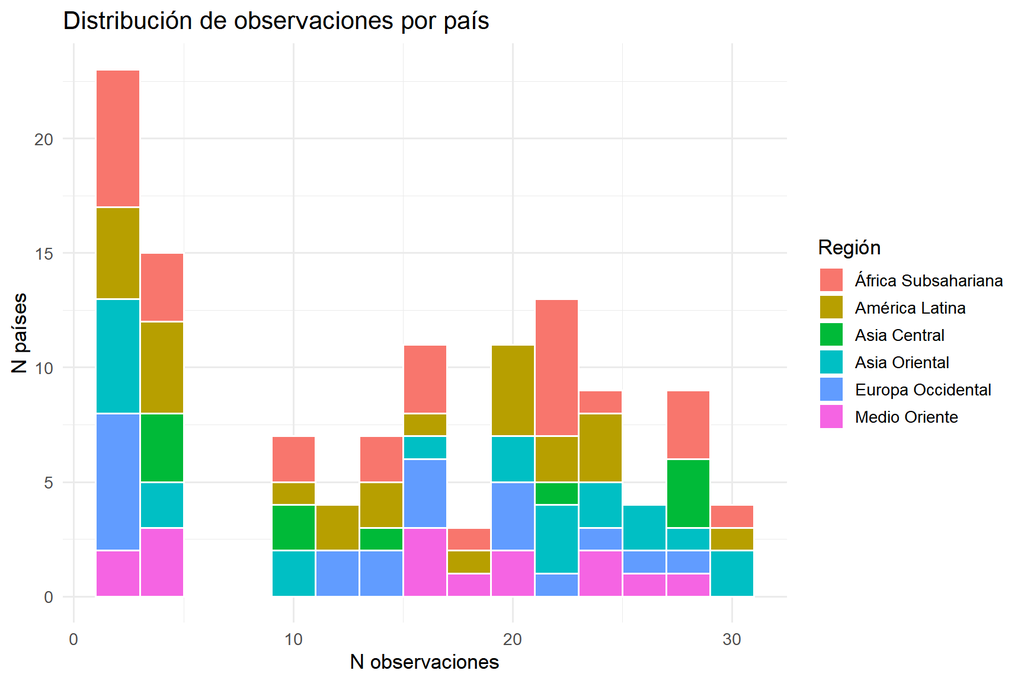

```r
obs_por_pais %>%
  ggplot(aes(x = n_obs, fill = region)) +
  geom_histogram(binwidth = 2, color = "white") +
  labs(title = "Distribución de observaciones por país",
       x = "N observaciones", y = "N países", fill = "Región")
```

# 2. Los Tres Modelos de Pooling

## 2.1 Conceptos Clave

| Modelo | Supuesto | Ventaja | Desventaja |
| --- | --- | --- | --- |
| **No Pooling** | Cada país es independiente | Estimaciones específicas | Mal desempeño con pocos datos |
| **Full Pooling** | Todos los países son iguales | Estable con pocos datos | Ignora heterogeneidad |
| **Partial Pooling** | Los países comparten información | Balancea ambos extremos | Más complejo |

El **partial pooling** (modelo multinivel) es el corazón de la estimación bayesiana jerárquica. Los coeficientes de cada país son atraídos hacia el promedio del grupo — fenómeno llamado **shrinkage** — siendo este efecto mayor cuando el país tiene **menos datos**.

## 2.2 Priors

Definimos priors con información económica razonable:

```r
# log(GDP per capita) ~ 7–11 para la mayoría de países
# Pendiente del gasto: efecto pequeño y positivo esperado
# Variación entre países: moderada

# No pooling: formula con 0 + pais elimina el intercepto global,
# todos los coeficientes quedan en class = b (no existe class = Intercept)
prior_nopool <- c(
  prior(normal(9, 1.5),   class = b),   # cubre interceptos por país
  prior(exponential(2),   class = sigma)
)

# Full pooling: tiene intercepto global → class = Intercept
# y una sola pendiente → class = b
prior_full <- c(
  prior(normal(9, 1.5),   class = Intercept),
  prior(normal(0.05, 0.1), class = b),
  prior(exponential(2),   class = sigma)
)

# Partial pooling: igual que full en efectos fijos,
# más hiperpriors para las desviaciones de los efectos aleatorios
prior_partial <- c(
  prior(normal(9, 1.5),   class = Intercept),
  prior(normal(0.05, 0.1), class = b),
  prior(exponential(1),   class = sd),     # variación entre grupos
  prior(exponential(2),   class = sigma)   # variación dentro del grupo
)
```

## 2.3 Modelo 1: No Pooling

Estimamos una ordenada al origen y pendiente **independiente** para cada país. Los países con pocos datos tienen estimaciones muy inciertas.

```r
# 0 + pais: sin intercepto global → todos los coefs en class = b
# gasto:pais: pendiente propia por país, sin pooling
m_nopool <- brm(
  formula = log_gdp ~ 0 + pais + gasto:pais,
  data    = datos_panel,
  prior   = prior_nopool,
  chains  = 4, cores = 4, iter = 2000, warmup = 1000,
  backend = "cmdstanr",
  seed    = 42,
  file    = "m_nopool"
)
```

```r
summary(m_nopool, priors = TRUE)
```

```
##  Family: gaussian
##   Links: mu = identity; sigma = identity
## Formula: log_gdp ~ 0 + pais + gasto:pais
##    Data: datos_panel (Number of observations: 1807)
##   Draws: 4 chains, each with iter = 2000; warmup = 1000; thin = 1;
##          total post-warmup draws = 4000
##
## Priors:
## b ~ normal(9, 1.5)
## <lower=0> sigma ~ exponential(2)
##
## Regression Coefficients:
##                  Estimate Est.Error l-95% CI u-95% CI Rhat Bulk_ESS Tail_ESS
## paisÁfr_1            7.72      0.45     6.86     8.58 1.00     5561     3169
## paisÁfr_10           7.45      0.26     6.95     7.97 1.00     5268     2540
## paisÁfr_11           6.77      0.33     6.14     7.41 1.00     5159     2787
## paisÁfr_12           8.30      0.27     7.77     8.81 1.00     6144     3114
## paisÁfr_13           7.55      0.32     6.92     8.17 1.00     6531     3050
## paisÁfr_14           8.53      0.25     8.03     9.02 1.00     6992     2704
## paisÁfr_15           6.44      0.32     5.81     7.08 1.00     7224     2932
## paisÁfr_16           8.14      0.38     7.40     8.91 1.00     6168     3031
## paisÁfr_17           7.67      0.27     7.15     8.20 1.00     6568     2647
## paisÁfr_18           6.93      0.36     6.25     7.65 1.00     6947     3056
## paisÁfr_19           8.20      0.31     7.61     8.81 1.00     5654     3047
## paisÁfr_2            7.68      0.38     6.95     8.43 1.00     5918     3104
## paisÁfr_20           8.99      0.84     7.32    10.62 1.00     5446     3222
## paisÁfr_21           8.93      0.95     7.04    10.80 1.00     5369     2884
## paisÁfr_22           8.24      0.84     6.59     9.91 1.00     6055     3091
## paisÁfr_23           7.22      0.88     5.51     8.93 1.00     5409     2505
## paisÁfr_24           8.14      0.67     6.80     9.47 1.00     4935     3021
## paisÁfr_25           7.72      0.77     6.20     9.22 1.00     6410     2724
## paisÁfr_26           6.59      0.45     5.69     7.48 1.00     6384     3244
## paisÁfr_27           7.87      0.97     5.95     9.80 1.00     6666     2738
## paisÁfr_28           7.78      0.57     6.66     8.92 1.00     5733     2763
## paisÁfr_3            6.70      0.24     6.23     7.16 1.00     5980     2929
## paisÁfr_4            7.86      0.44     6.99     8.74 1.00     7036     2786
## paisÁfr_5            7.42      0.47     6.52     8.34 1.00     6162     2991
## paisÁfr_6            7.59      0.28     7.04     8.14 1.00     6929     3393
## paisÁfr_7            8.45      0.36     7.73     9.17 1.00     5325     2628
## paisÁfr_8            7.71      0.27     7.20     8.25 1.00     6302     3012
```

[output cut: 186 more lines]

```
## paisMed_3:gasto      0.12      0.01     0.11     0.14 1.00     6651     2935
## paisMed_4:gasto      0.06      0.01     0.04     0.08 1.00     6867     2833
## paisMed_5:gasto      0.09      0.01     0.07     0.10 1.00     4859     2705
## paisMed_6:gasto      0.11      0.01     0.09     0.12 1.00     6313     3056
## paisMed_7:gasto      0.08      0.01     0.06     0.10 1.00     5834     2723
## paisMed_8:gasto      0.04      0.01     0.03     0.06 1.00     5942     2754
## paisMed_9:gasto      0.05      0.01     0.03     0.06 1.00     6424     2586
##
## Further Distributional Parameters:
##       Estimate Est.Error l-95% CI u-95% CI Rhat Bulk_ESS Tail_ESS
## sigma     0.42      0.01     0.41     0.44 1.00     7236     3405
##
## Draws were sampled using sample(hmc). For each parameter, Bulk_ESS
## and Tail_ESS are effective sample size measures, and Rhat is the potential
## scale reduction factor on split chains (at convergence, Rhat = 1).
```

## 2.4 Modelo 2: Full Pooling

Un solo intercepto y pendiente para todos los países. **Ignora la estructura de datos**.

```r
m_full <- brm(
  formula = log_gdp ~ 1 + gasto,
  data    = datos_panel,
  prior   = prior_full,
  chains  = 4, cores = 4, iter = 2000, warmup = 1000,
  backend = "cmdstanr",
  seed    = 42,
  file    = "m_full"
)
```

```r
summary(m_full)
```

```
##  Family: gaussian
##   Links: mu = identity; sigma = identity
## Formula: log_gdp ~ 1 + gasto
##    Data: datos_panel (Number of observations: 1807)
##   Draws: 4 chains, each with iter = 2000; warmup = 1000; thin = 1;
##          total post-warmup draws = 4000
##
## Regression Coefficients:
##           Estimate Est.Error l-95% CI u-95% CI Rhat Bulk_ESS Tail_ESS
## Intercept     8.78      0.08     8.63     8.93 1.00     5579     2821
## gasto         0.08      0.00     0.07     0.08 1.00     5522     3071
##
## Further Distributional Parameters:
##       Estimate Est.Error l-95% CI u-95% CI Rhat Bulk_ESS Tail_ESS
## sigma     0.99      0.02     0.96     1.02 1.00     2581     2314
##
## Draws were sampled using sample(hmc). For each parameter, Bulk_ESS
## and Tail_ESS are effective sample size measures, and Rhat is the potential
## scale reduction factor on split chains (at convergence, Rhat = 1).
```

## 2.5 Modelo 3: Partial Pooling (Multinivel)

Interceptos y pendientes varían por **país** y por **región**, compartiendo información entre niveles.

```r
# Nivel 1: observación
# Nivel 2: país (anidado en región)
# Nivel 3: región

m_partial <- brm(
  formula = log_gdp ~ 1 + gasto +
    (1 + gasto | region / pais),   # efectos aleatorios anidados
  data    = datos_panel,
  prior   = prior_partial,
  chains  = 4, cores = 4, iter = 2000, warmup = 1000,
  backend = "cmdstanr",
  control = list(adapt_delta = 0.95),
  seed    = 42,
  file    = "m_partial"
)
```

```r
summary(m_partial)
```

[output not shown]

# 3. Diagnósticos MCMC

```r
# brmsfit usa summary() para obtener R-hat y Bulk/Tail ESS directamente
diagnosticos <- as.data.frame(summary(m_partial)$fixed)
cat("R-hat máximo (efectos fijos):", max(diagnosticos$Rhat, na.rm = TRUE), "\n")
```

```
## R-hat máximo (efectos fijos): 1.003162
```

```r
cat("Bulk ESS mínimo:             ", min(diagnosticos$Bulk_ESS, na.rm = TRUE), "\n")
```

```
## Bulk ESS mínimo:              3197.056
```

```r
cat("Tail ESS mínimo:             ", min(diagnosticos$Tail_ESS, na.rm = TRUE), "\n")
```

```
## Tail ESS mínimo:              3488.832
```

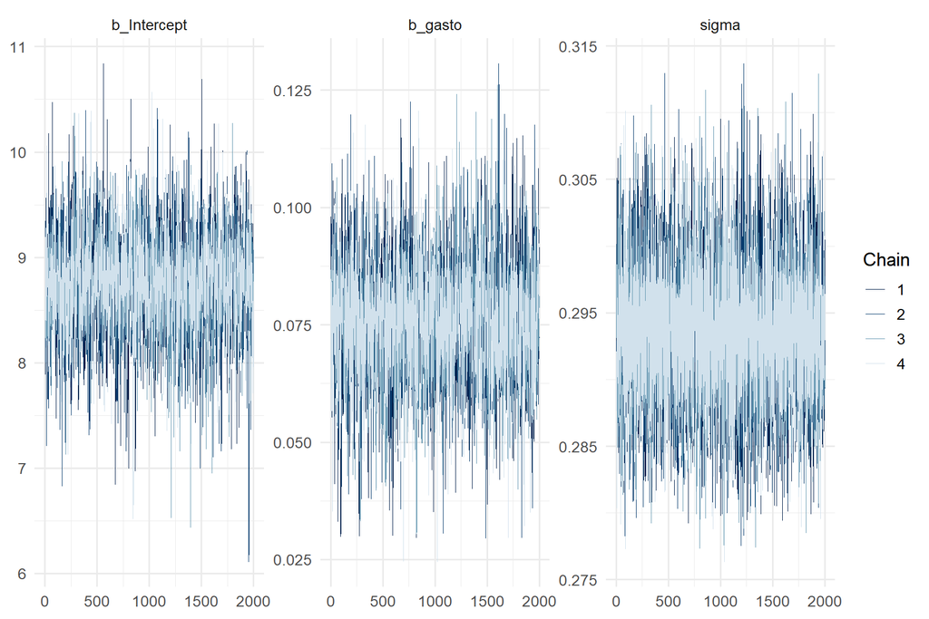

```r
# Trace plots — convertir a array primero para bayesplot
posterior_array <- as.array(m_partial)
mcmc_trace(posterior_array, pars = c("b_Intercept", "b_gasto", "sigma"))
```

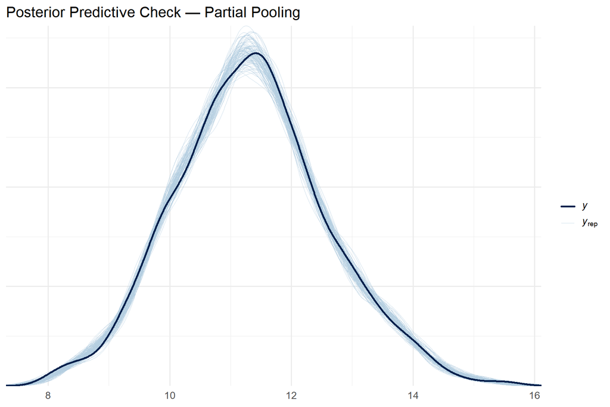

```r
# Posterior predictive check
pp_check(m_partial, ndraws = 100) +
  labs(title = "Posterior Predictive Check — Partial Pooling")
```

# 4. El Efecto Shrinkage

El resultado más importante del partial pooling: los países con **pocos datos** son “jalados” hacia el promedio regional.

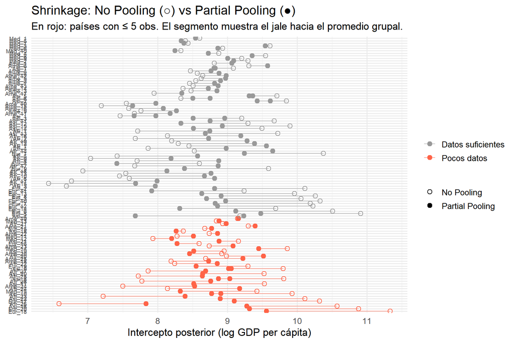

```r
# Con (1 + gasto | region/pais), brms nombra el nivel anidado "region:pais"
# Verificar nombres reales de los grouping factors:
# names(coef(m_partial))  →  "region"  "region:pais"

# Lista de países válidos en los datos (sin pendientes)
paises_validos <- datos_panel %>% distinct(pais) %>% pull(pais)

# --- No pooling: filtrar solo interceptos usando la lista de países conocidos
# brms genera "b_paisAmé_1" (intercepto) y "b_paisAmé_1:gasto" (pendiente)
coef_nopool <- as_draws_df(m_nopool) %>%
  select(starts_with("b_pais")) %>%
  pivot_longer(everything(), names_to = "param", values_to = "valor") %>%
  mutate(pais = str_remove(param, "^b_pais")) %>%
  filter(pais %in% paises_validos) %>%          # solo interceptos válidos
  group_by(pais) %>%
  summarise(est_nopool = mean(valor), sd_nopool = sd(valor))

# --- Partial pooling: rownames tienen formato "NombreRegion_CodPais"
# p.ej. "África Subsahariana_Áfr_1" donde el país es "Áfr_1"
# Construimos tabla de lookup: region_pais_key → pais
lookup <- datos_panel %>%
  distinct(region, pais) %>%
  mutate(rp_key = paste(region, pais, sep = "_"))

coef_partial <- coef(m_partial)[["region:pais"]][, , "Intercept"] %>%
  as.data.frame() %>%
  rownames_to_column("rp_key") %>%
  left_join(lookup, by = "rp_key") %>%
  select(pais, est_partial = Estimate, sd_partial = Est.Error)

# distinct(pais, region) puede dar duplicados si un país aparece en varias regiones
# usamos slice(1) para garantizar una sola fila por país
region_pais <- datos_panel %>%
  distinct(pais, region) %>%
  group_by(pais) %>%
  slice(1) %>%
  ungroup()

comparacion <- coef_nopool %>%
  left_join(coef_partial,                        by = "pais") %>%
  left_join(obs_por_pais %>% select(pais, n_obs), by = "pais") %>%
  left_join(region_pais,                          by = "pais") %>%
  mutate(escaso = pais %in% paises_escasos)

# Cleveland dot plot: cada fila es un país,
# segmento conecta No Pooling (○) con Partial Pooling (●)
comparacion_long <- comparacion %>%
  pivot_longer(c(est_nopool, est_partial),
               names_to = "modelo", values_to = "estimacion") %>%
  mutate(modelo = recode(modelo,
    est_nopool  = "No Pooling",
    est_partial = "Partial Pooling"
  ))

# unique() garantiza que orden_paises no tenga duplicados
orden_paises <- comparacion %>%
  mutate(shrinkage = abs(est_nopool - est_partial)) %>%
  arrange(desc(escaso), desc(shrinkage)) %>%
  pull(pais) %>%
  unique()

comparacion_long %>%
  mutate(pais = factor(pais, levels = orden_paises)) %>%
  ggplot(aes(x = estimacion, y = pais)) +
  geom_line(aes(group = pais, color = escaso), linewidth = 0.5, alpha = 0.6) +
  geom_point(aes(shape = modelo, color = escaso), size = 2.5) +
  scale_shape_manual(values = c("No Pooling" = 1, "Partial Pooling" = 19),
                     name = NULL) +
  scale_color_manual(values = c("FALSE" = "gray60", "TRUE" = "tomato"),
                     labels = c("FALSE" = "Datos suficientes", "TRUE" = "Pocos datos"),
                     name = NULL) +
  labs(
    title    = "Shrinkage: No Pooling (○) vs Partial Pooling (●)",
    subtitle = "En rojo: países con ≤ 5 obs. El segmento muestra el jale hacia el promedio grupal.",
    x        = "Intercepto posterior (log GDP per cápita)",
    y        = NULL
  ) +
  theme(axis.text.y = element_text(size = 7))
```

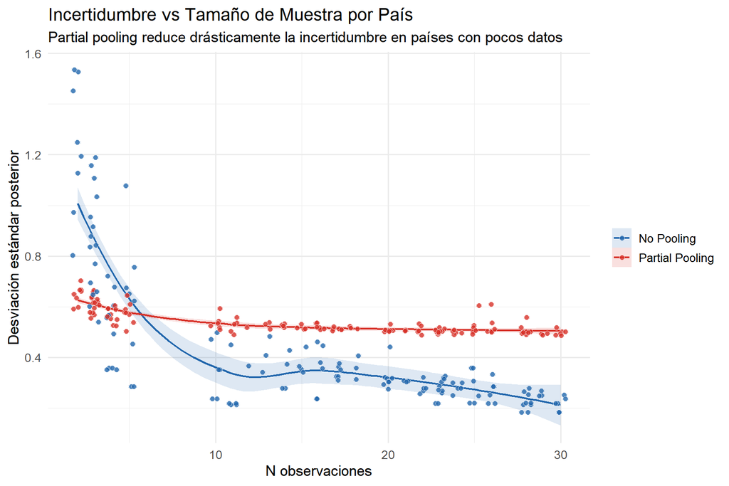

```r
# Separar las dos series con position_dodge para que no se solapen
comparacion %>%
  pivot_longer(c(sd_nopool, sd_partial), names_to = "modelo", values_to = "sd") %>%
  mutate(modelo = recode(modelo,
    sd_nopool  = "No Pooling",
    sd_partial = "Partial Pooling"
  )) %>%
  ggplot(aes(x = n_obs, y = sd, color = modelo, fill = modelo)) +
  # línea de tendencia primero (fondo)
  geom_smooth(se = TRUE, alpha = 0.15, linewidth = 0.8) +
  # puntos con jitter horizontal para separar solapamientos
  geom_jitter(width = 0.3, height = 0, size = 2, alpha = 0.8, shape = 21,
              color = "white", stroke = 0.3) +
  scale_color_manual(values = c("No Pooling" = "#2166ac", "Partial Pooling" = "#d73027")) +
  scale_fill_manual( values = c("No Pooling" = "#2166ac", "Partial Pooling" = "#d73027")) +
  labs(
    title    = "Incertidumbre vs Tamaño de Muestra por País",
    subtitle = "Partial pooling reduce drásticamente la incertidumbre en países con pocos datos",
    x        = "N observaciones", y = "Desviación estándar posterior",
    color    = NULL, fill = NULL
  )
```

# 5. Predicciones Regionales

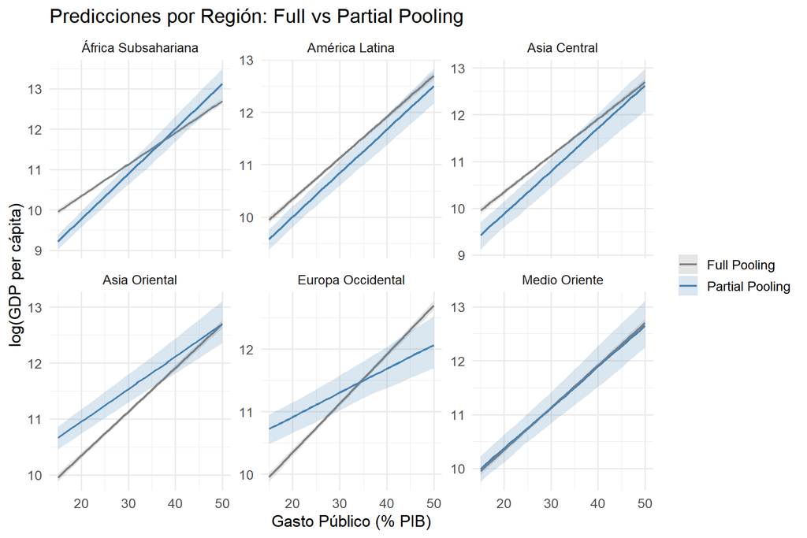

```r
# Grid de predicción para cada región
grid_pred <- datos_panel %>%
  distinct(region) %>%
  crossing(gasto = seq(15, 50, length.out = 50))

# Solo podemos hacer predicciones "de población" con partial pooling
pred_full    <- add_epred_draws(m_full,    newdata = grid_pred, ndraws = 200)
pred_partial <- add_epred_draws(m_partial, newdata = grid_pred,
                                re_formula = ~ (1 + gasto | region), ndraws = 200)

# Comparar intervalos de credibilidad
bind_rows(
  pred_full    %>% mutate(modelo = "Full Pooling"),
  pred_partial %>% mutate(modelo = "Partial Pooling")
) %>%
  group_by(modelo, region, gasto) %>%
  median_qi(.epred, .width = 0.89) %>%
  ggplot(aes(x = gasto, y = .epred, color = modelo, fill = modelo)) +
  geom_line(linewidth = 0.8) +
  geom_ribbon(aes(ymin = .lower, ymax = .upper), alpha = 0.2, color = NA) +
  facet_wrap(~ region, scales = "free_y") +
  scale_color_manual(values = c("gray50", "steelblue")) +
  scale_fill_manual(values  = c("gray50", "steelblue")) +
  labs(
    title   = "Predicciones por Región: Full vs Partial Pooling",
    x       = "Gasto Público (% PIB)", y = "log(GDP per cápita)",
    color   = NULL, fill = NULL
  )
```

# 6. Comparación de Modelos

## 6.1 Leave-One-Out Cross-Validation (LOO)

```r
# moment_match = TRUE es incompatible con backend cmdstanr (requiere rstan)
# Si hay warnings de k > 0.7, se puede usar reloo = TRUE en su lugar
loo_full    <- loo(m_full)
loo_partial <- loo(m_partial)

loo_compare(loo_full, loo_partial)
```

```
##           elpd_diff se_diff
## m_partial     0.0       0.0
## m_full    -2071.5      40.5
```

## 6.2 Visualización del Ajuste

[figure not shown]

```r
# Comparar las tres estrategias para países con pocos datos
muestra_paises <- sample(paises_escasos, 6)

datos_muestra <- datos_panel %>% filter(pais %in% muestra_paises)

grid_pais <- datos_muestra %>%
  group_by(pais, region) %>%
  summarise(gasto = seq(min(gasto) - 5, max(gasto) + 5, length.out = 40),
            .groups = "drop")

# No pooling: no tiene efectos aleatorios, todos los coefs son fijos (b_)
# allow_new_levels=FALSE porque el modelo solo conoce los países del training
pred_np <- add_epred_draws(m_nopool, newdata = grid_pais,
                           ndraws = 100) %>%
  mutate(modelo = "No Pooling")

# Full pooling: un solo intercepto global, re_formula=NA es correcto aquí
pred_fp <- add_epred_draws(m_full, newdata = grid_pais,
                           re_formula = NA, ndraws = 100) %>%
  mutate(modelo = "Full Pooling")

pred_pp <- add_epred_draws(m_partial, newdata = grid_pais, ndraws = 100) %>%
  mutate(modelo = "Partial Pooling")

bind_rows(pred_np, pred_fp, pred_pp) %>%
  group_by(modelo, pais, gasto) %>%
  median_qi(.epred, .width = 0.89) %>%
  ggplot(aes(x = gasto, y = .epred, color = modelo, fill = modelo)) +
  geom_ribbon(aes(ymin = .lower, ymax = .upper), alpha = 0.15, color = NA) +
  geom_line(linewidth = 0.9) +
  geom_point(data = datos_muestra, aes(x = gasto, y = log_gdp),
             inherit.aes = FALSE, size = 2, color = "black") +
  facet_wrap(~ pais, scales = "free") +
  scale_color_manual(values = c("gray40", "steelblue", "tomato")) +
  scale_fill_manual(values  = c("gray40", "steelblue", "tomato")) +
  labs(
    title    = "Comparación de los Tres Modelos — Países con Pocos Datos",
    subtitle = "Puntos negros = datos observados. El partial pooling balancea sesgo e incertidumbre.",
    x        = "Gasto Público (% PIB)", y = "log(GDP per cápita)",
    color    = NULL, fill = NULL
  )
```

# 7. Inferencia

## 7.1 Efecto del Gasto Público por Región

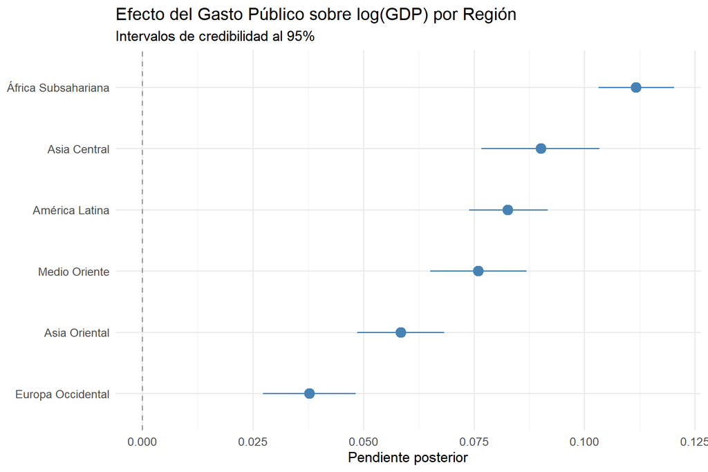

```r
# Extraer pendientes regionales del partial pooling
pendientes_region <- coef(m_partial)$region[, , "gasto"] %>%
  as.data.frame() %>%
  rownames_to_column("region")

pendientes_region %>%
  ggplot(aes(x = reorder(region, Estimate),
             y = Estimate, ymin = Q2.5, ymax = Q97.5)) +
  geom_pointrange(size = 0.8, color = "steelblue") +
  geom_hline(yintercept = 0, linetype = "dashed", color = "gray60") +
  coord_flip() +
  labs(
    title = "Efecto del Gasto Público sobre log(GDP) por Región",
    subtitle = "Intervalos de credibilidad al 95%",
    x = NULL, y = "Pendiente posterior"
  )
```

## 7.2 Hipótesis y contrastes

```r
# aleatorios (r_region[]). Usamos as_draws_df con los nombres exactos.
draws_contraste <- as_draws_df(m_partial) %>%
  mutate(diferencia = `r_region[Europa.Occidental,gasto]` -
                      `r_region[África.Subsahariana,gasto]`)

cat("P(β_Europa < β_África):", mean(draws_contraste$diferencia < 0), "\n")
```

```
## P(β_Europa < β_África): 1
```

```r
cat("IC 89%: [",
    round(quantile(draws_contraste$diferencia, 0.055), 4), ",",
    round(quantile(draws_contraste$diferencia, 0.945), 4), "]\n")
```

```
## IC 89%: [ -0.0851 , -0.0625 ]
```

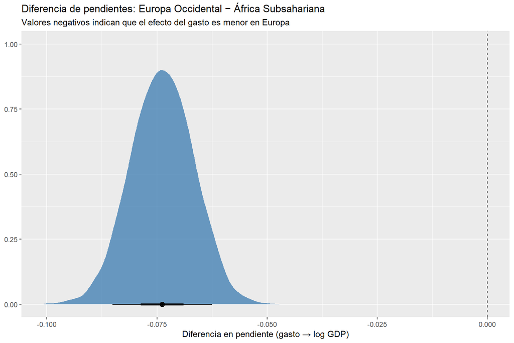

```r
# Visualizar la distribución posterior de la diferencia
draws_contraste %>%
  ggplot(aes(x = diferencia)) +
  stat_halfeye(.width = c(0.5, 0.89), fill = "steelblue", alpha = 0.8) +
  geom_vline(xintercept = 0, linetype = "dashed") +
  labs(
    title    = "Diferencia de pendientes: Europa Occidental − África Subsahariana",
    subtitle = "Valores negativos indican que el efecto del gasto es menor en Europa",
    x = "Diferencia en pendiente (gasto → log GDP)", y = NULL
  )
```

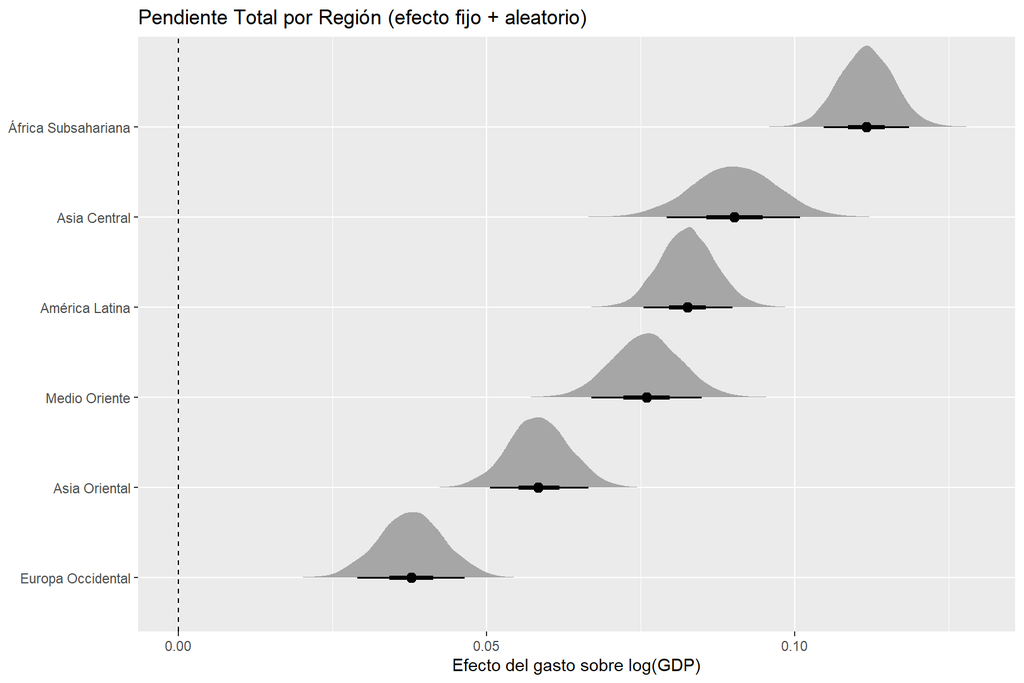

```r
# Extraer el efecto fijo global de gasto
beta_gasto <- fixef(m_partial)["gasto", "Estimate"]

m_partial %>%
  spread_draws(r_region[region, term], b_gasto) %>%
  filter(term == "gasto") %>%
  mutate(
    region    = gsub(".", " ", region, fixed = TRUE),
    pendiente_total = r_region + b_gasto    # efecto aleatorio + fijo
  ) %>%
  ggplot(aes(x = pendiente_total, y = reorder(region, pendiente_total))) +
  stat_halfeye(.width = c(0.5, 0.89)) +
  geom_vline(xintercept = 0, linetype = "dashed") +
  labs(
    title = "Pendiente Total por Región (efecto fijo + aleatorio)",
    x = "Efecto del gasto sobre log(GDP)", y = NULL
  )
```

# 8. Resumen

```r
tibble(
  Modelo           = c("No Pooling", "Full Pooling", "Partial Pooling"),
  Parámetros       = c("2 × N_países", "2", "2 + 2×N_grupos (hiperparámetros)"),
  `Países escasos` = c("Alta incertidumbre", "Sesgo por pooling total", "Shrinkage óptimo"),
  `Predicción OOS` = c("Mala", "Regular", "Mejor"),
  Interpretación   = c("Directa por país", "Solo efecto promedio", "Efectos por nivel")
) %>%
  knitr::kable(caption = "Comparación de estrategias de pooling")
```

Comparación de estrategias de pooling

| Modelo | Parámetros | Países escasos | Predicción OOS | Interpretación |
| --- | --- | --- | --- | --- |
| No Pooling | 2 × N_países | Alta incertidumbre | Mala | Directa por país |
| Full Pooling | 2 | Sesgo por pooling total | Regular | Solo efecto promedio |
| Partial Pooling | 2 + 2×N_grupos (hiperparámetros) | Shrinkage óptimo | Mejor | Efectos por nivel |

# Apéndice: Especificación del Modelo Multinivel

$$\log(\text{GDP}_{ij}) = \alpha_j + \beta_j \cdot \text{Gasto}_{ij} +
\varepsilon_{ij}$$

**Nivel país** ($j$):
$$\alpha_j \sim \mathcal{N}(\mu_{\alpha_r}, \sigma_\alpha), \quad
\beta_j \sim \mathcal{N}(\mu_{\beta_r}, \sigma_\beta)$$

**Nivel región** ($r$):
$$\mu_{\alpha_r} \sim \mathcal{N}(\bar{\alpha}, \tau_\alpha), \quad
\mu_{\beta_r} \sim \mathcal{N}(\bar{\beta}, \tau_\beta)$$

**Hiperpriors**:
$$\bar{\alpha} \sim \mathcal{N}(9, 1.5), \quad \bar{\beta} \sim
\mathcal{N}(0.05, 0.1)$$
$$\sigma_\alpha, \sigma_\beta, \tau_\alpha, \tau_\beta \sim
\text{Exponencial}(1), \quad
\varepsilon \sim \mathcal{N}(0, \sigma)$$

En `brms` esto se expresa como:

```r
log_gdp ~ 1 + gasto + (1 + gasto | region / pais)
```